# Python en Physique-Chimie

Le but de ce notebook est de vous rappeler toutes les possibilités intéressantes que vous offre Python en Physique-Chimie, en TP ou pour la résolution numérique de problèmes.

# Travailler avec des données issues de mesures

## Importer des données depuis un tableur

Retour à la table des matières

Vous avez réalisé un jeu de mesures sur un tableur et avez obtenu un fichier type `.xls` ou `.xlsx` à l'aide d'Excel ou Libre Office.

**Comment l'importer rapidement sur Python ?**

Nous allons pour cela utiliser les modules :

- `pandas` et `xlrd`pour l'import des données depuis le tableur
- `matplotlib.pyplot` pour les tracés
- `numpy`pour le traitement des tableaux

```python
import pandas as pd
import numpy as np
import matplotlib.pyplot as plt
import xlrd
```

Dans un premier temps, on récupère les données qui sont dans le tableur. Une bonne pratique est que chaque grandeur corresponde à une colonne du tableur, et que la première ligne corresponde au nom de la grandeur et à son unité. Par exemple, dans notre fichier `determinationg.xls`, les trois premières lignes sont :

| $$\Delta t \mbox{ (s) }$$ | $$u(\Delta t) \mbox{ (s) }$$ | $$h \mbox{ (m) }$$ | $$u(h) \mbox{ (m) }$$ |
| --- | --- | --- | --- |
| 0,25 | 0,05 | 0,5 | 0,02 |
| 0,42 | 0,05 | 0,75 | 0,02 |

On va importer les données du tableur dans Python sous la forme d'un `DataFrame`, appelé `mesdonnees` ci-dessous, à l'aide de la fonction `read_excel`:

```python
mesdonnees = pd.read_excel("determinationg.xls")
# si le chemin relatif ne fonctionne pas, vous pouvez indiquer le chemin absolu
# avec des // comme "C://Users//etc//monfichier.xlsx
```

Il ne reste plus désormais qu'à récupérer chaque colonne du tableur sous forme d'un tableau `numpy` à l'aide de la méthode `values` suivante :

```python
deltat=mesdonnees.values[:,0]
# les : indiquent que l'on prend toutes les lignes,
# le deuxième argument indique la colonne, la première étant repérée par 0
u_deltat=mesdonnees.values[:,1]
h=mesdonnees.values[:,2]
u_h=mesdonnees.values[:,3]
```

On peut vérifier que l'on a bien récupéré ce que l'on voulait :

```python
deltat
```

```
array([0.25, 0.42, 0.5 , 0.53, 0.53, 0.58, 0.72, 0.6 , 0.8 , 0.7 , 0.7 ])
```

```python
u_deltat
```

```
array([0.05, 0.05, 0.05, 0.05, 0.05, 0.05, 0.05, 0.05, 0.05, 0.05, 0.05])
```

```python
h
```

```
array([0.5 , 0.75, 1.  , 1.25, 1.5 , 1.75, 2.  , 2.25, 2.5 , 2.75, 3.  ])
```

```python
u_h
```

```
array([0.02, 0.02, 0.02, 0.02, 0.02, 0.02, 0.02, 0.02, 0.02, 0.02, 0.02])
```

## Tracer une courbe avec les incertitudes

Retour à la table des matières

On s'intéresse à la durée d'une chute libre en fonction de la hauteur du lâcher. On a réalisé des expériences et on dispose de 4 tableaux `numpy` depuis un tableur :

- `h` les hauteurs de lâché en m
- `u_h` les incertitudes type associées en m
- `deltat` les durées de chute en s
- `u_deltat` les incertitudes type associées en s

**Comment tracer de manière élégante $\Delta t(h)$ en faisant apparaître les incertitudes type ?**

Nous allons utiliser pour cela le module `matplotlib.pyplot`.

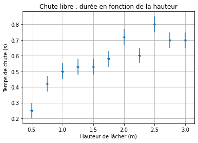

```python
import matplotlib.pyplot as plt

plt.figure() #créeons une nouvelle figure
plt.errorbar(h,deltat,xerr=u_h,yerr=u_deltat,fmt='.') #les incertitudes type sont placées dans les arguments xerr et yerr
# fmt='.' permet de ne pas relier les points (chaque mesure est un point + barre d'incertitude)
plt.grid(which='both') #on ajoute des grilles verticales et horizontales
plt.xlabel("Hauteur de lâcher (m)") #on nomme l'axe horizontal
plt.ylabel("Temps de chute (s)") #on nomme l'axe vertical
plt.title("Chute libre : durée en fonction de la hauteur") # titre
plt.show()
```

## Réaliser une modélisation via Python

Retour à la table des matières

On s'intéresse à la durée d'une chute libre en fonction de la hauteur du lâcher. On a réalisé des expériences et on dispose de 4 tableaux `numpy` depuis un tableur :

- `h` les hauteurs de lâcher en m
- `u_h` les incertitudes type associées en m
- `deltat` les durées de chute en s *`u_deltat` les incertitudes type associées en s

Dans la partie précédente, on a fait le tracé de $\Delta t$ en fonction de h. On sait que l'expression théorique associée est : $$\Delta t = \sqrt{\frac{2h}{g}}$$ où $g$ est le champ de pesanteur.

### Cas 1 - Fonction polynomiale (ex : régression linéaire) - `polyfit`- au programme

Nous allons maintenant devoir effectuer la modélisation de notre jeu de données par une fonction affine. Pour cela, nous pouvons utiliser la fonction `polyfit(x,y,N)` du module `numpy`. Cette fonction trouve le polynôme de degré $N$ qui modélise au mieux le jeu de données `y(x)`. Le cas $N=1$ correspond à la régression linéaire.

Cette fonction renvoie la liste des coefficients $a_k$ (par valeur décroissante de $k$) du polynôme modèle estimé tel que :

$$y_{\mbox{modele}}(x)=\sum_{k=1}^N a_k x^k $$

Le modèle trouvé par la fonction est celui qui minimise l’erreur quadratique totale : $$\chi^2= \sum_{\mbox{points de mesures i}} \left[y_i(x_i)-y_{\mbox{modele}}(x_i)\right]^2 $$

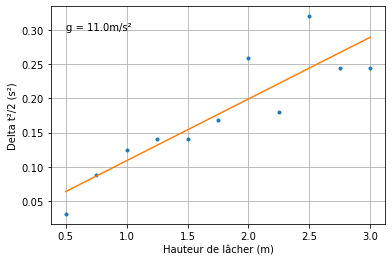

```python
coeffs_modele=np.polyfit(h,1/2*deltat**2,1)
p=coeffs_modele[0] # pente=1/g
b=coeffs_modele[1] # ordonnée à l'origine

g=1/p

def droite_modele(x):
    return p*x+b

plt.plot(h,1/2*deltat**2,'.')
plt.ylabel("Delta t²/2 (s²)")
plt.xlabel("Hauteur de lâcher (m)")
plt.grid(which='both')
plt.plot(h,droite_modele(h)) #tracé de la droite modèle en plus des mesures
plt.text(0.5,0.3,"g = "+str(g)[0:4]+ "m/s²")
```

### Cas 2 - Modélisation par fonction quelconque - `curve_fit`- HP mais pratique

On peut aussi ne pas se limiter au regressions polynomiales et chercher la courbe dont l'équation est la précédente ($\Delta t = \sqrt{\frac{2h}{g}}$) , et qui passe au mieux par les points de mesure. Il en déduira alors la valeur de $g$.

Voici la démarche générale (ne pas compiler) :

```
from scipy.optimize import curve_fit

def f(x,a,b,c,d): # mettre la variable puis les paramètres à estimer en argument.
    return a*x**3+b*x**2+c*x+d # mettre ici l'expression à approcher

x = [...] # rentrer ici le tableau des mesures de x
y = [...] # rentrer ici le tableau des mesures de y associées

p_estimation,p_err=curve_fit(f, x, y)  #p_estimation est la liste des paramètres estimés
p_type=np.sqrt(np.diag(p_err)) #p_type est la liste des incertitudes type sur l'estimation des paramètres

## ne pas oublier de finir par un tracé superposant les points de mesure et la courbe théorique estimée pour valider l'estimation.

## si la modélisation ne converge pas, on peut « aider » curve_fit, en lui donnant une première estimation des paramètres dans un argument p0=[aestime,bestime,cestime,destime]
```

Mettons la en application sur notre exemple :

```python
from scipy.optimize import curve_fit # c'est la fonction qui réalise l'ajustement
from math import sqrt

#tout d'abord on définit la fonction à modéliser

def f(x,g):
    return np.sqrt(2*x/g)

x=h
y=deltat

p_estimation,p_err=curve_fit(f, x, y)  #p_estimation est la liste des paramètres estimés
p_type=np.sqrt(np.diag(p_err)) #p_type est la liste des incertitudes type sur l'estimation des paramètres
```

Vérifions la valeur de $g$, ainsi que le tracé de la courbe modèle :

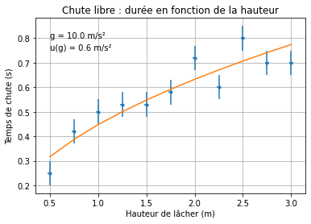

```python
g=p_estimation[0]
u_g=p_type[0]

#le tracé de nos mesures (cf chapitre précédent)
plt.figure()
plt.errorbar(h,deltat,xerr=u_h,yerr=u_deltat,fmt='.')
plt.grid(which='both') #on ajoute des grilles verticales et horizontales
plt.xlabel("Hauteur de lâcher (m)") #on nomme l'axe horizontal
plt.ylabel("Temps de chute (s)") #on nomme l'axe vertical
plt.title("Chute libre : durée en fonction de la hauteur") # titre (optionnel)

#le tracé de la modélisation
plt.plot(h,f(h,g))
plt.text(0.5,0.8,"g = "+str(g)[0:4]+" m/s²")
plt.text(0.5,0.75,"u(g) = "+str(u_g)[0:3]+" m/s²")

plt.show()
```

Avant d'accepter les valeurs déterminées par la modélisation on vérifie :

- que les points de mesure sont aléatoirement répartis autour de la courbe de modélisation : ok
- que la courbe est toujours "à proximité" des points (pas plus de 2 écarts-types) : ok, même si tout juste

Dans ce cas, on peut faire confiance au résultat :

$$g=10.0 m.s^{-2} ; u(g)=0.6 m.s^{-2}$$

(On ne garde qu'un seul chiffre significatif pour cette méthode de détermination de l'incertitude-type. Il faudrait une méthode de Monte Carlo pour en avoir deux, présentée un peu plus loin).

## Evaluer l'incertitude-type sur un paramètre inconnu avec Monte-Carlo

Retour à la table des matières

A l'issue d'une modélisation/ajustement d'une courbe avec `curve_fit`, on peut obtenir la valeur d'un paramètre inconnu ($g$ dans l'exemple plus haut, à relire absolument avant, associé à une incertitude-type $u(g)$. Cependant, nous ne savons pas comment est déterminée cette incertitude-type et on aimerait la déterminer nous-même pas un algorithme de type Monte-Carlo.

**Comment estimer l’incertitude-type sur les paramètres d’une fonction $f$ telle que $y=f(x)$ où $y$ et $x$ sont des grandeurs mesurées ?**

On dispose :

- d’un tableau `lx` des valeurs de $x$ mesurées, de longueur `n`
- d’un tableau `lux` des valeurs de $u(x)$ mesurées, de longueur `n`
- d’un tableau `ly` des valeurs de $y$ mesurées, de longueur `n`
- d’un tableau `lux` des valeurs de $u(y)$ mesurées, de longueur `n`

L'algorithe consiste en :

**Faire $N$ fois :**

- 1) Génération des tableaux simulés `lx_simu` et `ly_simu` avec une distribution aléatoire : $$\forall i \mbox{ lx_simu[i] est une valeur aléatoire tirée uniformément dans }$$ $$\left[lx[i]-\sqrt{3}\times lux[i];lx[i]+\sqrt{3}\times lux[i]\right]$$ On fait de même pour le tableau des $y$.
- 2) Estimation des paramètres inconnus à l'aide de `curve_fit` à partir de `lx_simu` et `ly_simu`. C'est la procédure classique présentée dans le paragraphe "Réaliser une modélisation sous Python".
- 3) Stockage des paramètres estimés dans une liste qui grandit à chaque itération.

**Après les $N$ étapes :** Observer l’histogramme du(des) paramètre(s) estimé(s) et calculer l’écart-type associé qui donne l’incertitude type sur le paramètre.

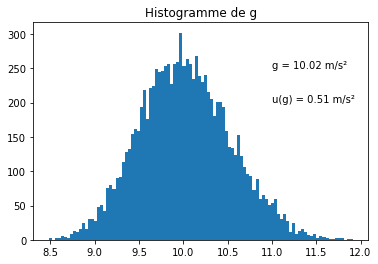

```python
## on reprend la détermination de g commencée plus haut

# on commence par ré-importer les données

import pandas as pd
import numpy as np
import matplotlib.pyplot as plt
from scipy.optimize import curve_fit # c'est la fonction qui réalise l'ajustement
from math import sqrt
import random as rd

mesdonnees = pd.read_excel("determinationg.xls")
deltat=mesdonnees.values[:,0]
u_deltat=mesdonnees.values[:,1]
h=mesdonnees.values[:,2]
u_h=mesdonnees.values[:,3]

# on redéfinit la fonction de modélisation

def f(x,g):
    return np.sqrt(2*x/g)

# on lance l'algorithme de Monte Carlo
liste_g=[]
N=10000
deltat_simu=np.zeros((len(deltat)))
h_simu=np.zeros((len(deltat)))
for k in range(N):
    # étape 1 : on génère les tableaux simulés
    for i in range(len(deltat)):
        deltat_simu[i]=rd.uniform(deltat[i]-sqrt(3)*u_deltat[i],deltat[i]+sqrt(3)*u_deltat[i])
        h_simu[i]=rd.uniform(h[i]-sqrt(3)*u_h[i],h[i]+sqrt(3)*u_h[i])
    # étape 2 : on estime les paramètres inconnus
    x=h_simu
    y=deltat_simu
    p_estimation,p_err=curve_fit(f, x, y)
    # étape 3 : on remplit la liste des g estimés
    liste_g.append(p_estimation[0])

gm=np.mean(np.array(liste_g))
ug=np.std(np.array(liste_g))

#tracés
plt.figure()
plt.title("Histogramme de g")
plt.hist(liste_g,bins=100)
plt.text(11,250,"g = "+str(gm)[0:5]+" m/s²")
plt.text(11,200,"u(g) = "+str(ug)[0:4]+" m/s²")
plt.show()
```

# Propager des incertitudes

## Propager les incertitudes avec Monte-Carlo

Retour à la table des matières

On dispose :

- d'une grandeur $x$ dont la valeur mesurée est $x_m$ associée à son incertitude-type $u(x)$
- d'une grandeur $y$ dont la valeur mesurée est $y_m$ associée à son incertitude-type $u(y)$.

**On veut calculer une grandeur $z=f(x,y)$ et estimer l'incertitude-type sur cette grandeur par un algorithme de Monte-Carlo**.

La démarche va se faire en trois temps :

1. On va générer aléatoirement des tableaux de valeurs de $x$ et $y$, de distribution uniforme, et cohérentes avec les valeurs des incertitudes-type (c'est à dire que, pour $x$, les valeurs sont uniformément réparties dans l'intervalle $\left[x-\sqrt{3}\times u(x) ; x+\sqrt{3}\times u(x)\right]$). Ces listes sont appelées `x` et `y` dans la suite.
2. Pour chaque couple `x[i],y[i]`, on calcule la valeur `z[i]=f(x[i],y[i])`
3. L'incertitude-type sur $z$ est l'écart-type du tableau de valeurs de $z$ qui vient d'être calculé.

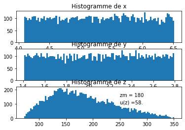

```python
import random as rd
import numpy as np
from math import sqrt
import matplotlib.pyplot as plt

def uniforme(m,u,N): # va renvoyer un tableau de N nombres aléatoire correspondant à une distribution uniforme
# centrée sur m et d'incertitude-type u
    x=[]
    a=m-sqrt(3)*u
    b=m+sqrt(3)*u
    for i in range(N):
        x.append(rd.uniform(a,b)) # la fonction rd.uniform renvoie un nombre aléatoire entre a et b (densité uniforme)
    return np.array(x)

## génération des tableaux x et y

xm= 5.3 # on rentre ici les données issues de l'expérience (grandeur mesurée et incertitude-type)
u_x=0.7

ym= 2.1
u_y=0.4

x=uniforme(xm,u_x,10000)
y=uniforme(ym,u_y,10000)

## définition de la fonction f

def f(x,y):
    return 3*x**2*y

## calcul de la liste des z

z=f(x,y)

## tracé des histogrammes et détermination de l'incertitude type sur z

plt.figure()

plt.subplot(311)
plt.hist(x,bins=100)
plt.title("Histogramme de x")

plt.subplot(312)
plt.hist(y,bins=100)
plt.title("Histogramme de y")

plt.subplot(313)
plt.hist(z,bins=100)
plt.title("Histogramme de z")

zm=np.mean(z)
um=np.std(z)

plt.text(250,150, "zm = "+str(zm)[0:3])
plt.text(250,100, "u(z) ="+str(um)[0:3])

plt.show()
```

# Réaliser des calculs mathématiques utiles

## Résoudre une équation différentielle

Retour à la table des matières

La résolution des équations différentielles peut s'effectuer, de manière numérique, en utilisant la méthode d'Euler.

Dans cette partie, nous allons voir une autre approche qui consiste à résoudre une équation-différentielle à l'aide de la fonction `odeint` du module `scipy.integrate`:

- Présentation de la résolution
- Exemple 1 : charge d'un circuit RC
- Exemple 2 : oscillation d'un pendule
- Exemple 3 : oscillateur à Pont de Wien

### Présentation

Revenir au menu de la résolution des équations différentielles

La résolution d'équations différentielles peut se faire efficacement à l'aide de la fonction `odeint` du module `scipy.integrate`. Pour l'utiliser, il faut écrire le problème à résoudre sous la forme : $$ \frac{dY}{dt}=F(Y,t)$$ $$Y(0)=Y_0$$

Si cette résolution semble a priori être uniquement celle d'une équation d'ordre 1, elle permet en fait de résoudre une équation d'ordre $N$ : il suffit alors que $Y$ soit un vecteur à $N$ éléments. Nous l'étudierons dans les exemples.

A chaque fois, il faudra donc:

1. Mettre le problème sous la forme demandée et en déduire la fonction $F$
2. Définir la fonction $F$ sous Python
3. Utiliser `y=odeint(F,y0,t,args=())` où `args` correspond aux arguments de $F$ qui ne sont ni $Y$ ni $t$ (et correspondent à des paramètres du problème par exemple). `t` est le tableau `numpy` correspondant aux instants où l'on cherche $Y$.

### 1er exemple simple : charge d'un condensateur

Revenir au menu de la résolution des équations différentielles

On cherche à déterminer la tension $s$ aux bornes d'un condensateur lors de la charge d'un circuit $RC$, régi par l'équation différentielle : $$s+\tau \frac{ds}{dt}=E$$ $$s(0)=0$$

Le problème se met donc sous la forme : $$\frac{ds}{dt}=\frac{E-s}{\tau}=F(s,t)$$ $$s(0)=0$$

Définissons $F$ :

```python
def F(s,t,E,tau): # on met les paramètres du problème (E,tau) en dernier
    return (E-s)/tau
```

Exécutons la fonction `odeint` et traçons le résultat :

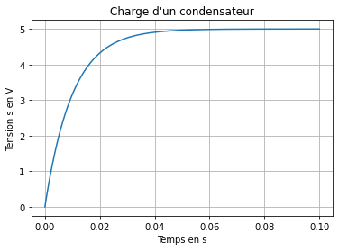

```python
from scipy.integrate import odeint
from scipy.integrate import odepack
import numpy as np
import matplotlib.pyplot as plt

s0=0
tau=10e-3
E=5
t=np.linspace(0,10*tau,1000)

y=odeint(F,s0,t,args=(E,tau))

plt.figure()
plt.plot(t,y)
plt.xlabel("Temps en s")
plt.ylabel("Tension s en V")
plt.grid()
plt.title("Charge d'un condensateur")
plt.show()
```

### 2ème exemple : équation non linéaire d'ordre 2 - le pendule simple

Revenir au menu de la résolution des équations différentielles

On s'intéresse désormais à l'équation non linéaire d'ordre 2 modélisation les oscillations d'un pendule de longueur $l$, de masse $m$ et soumis à une force de frottement fluide de coefficient $h$ : $$\frac{d^2 \theta}{dt^2}+\frac{h}{m} \frac{d\theta}{dt}+\frac{g}{l}\sin(\theta)=0$$ On poser les conditions initiales suivantes : $$\theta(t=0)=\theta_0$$ $$\frac{d\theta}{dt}(t=0)=\omega_0$$ Pour se ramener au problème d'ordre 1 résolu par `odeint`, on va poser le vecteur : $$Y= \begin{bmatrix} \theta \\ \dot{\theta}\end{bmatrix}$$ On déduit : $$\dot{Y}= \begin{bmatrix} \dot{\theta} \\ \ddot{\theta} \end{bmatrix}=\begin{bmatrix} \dot{\theta} \\ -\frac{h}{m} \dot{\theta}-\frac{g}{l}\sin(\theta) \end{bmatrix} = F(Y,t)$$ Définissons $F$ sous Python :

```python
def F(Y,t,h,m,g,l):
    return Y[1],-h/m*Y[1]-g/l*sin(Y[0])
```

Résolvons ensuite l'équation :

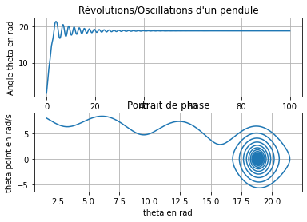

```python
from scipy.integrate import odeint
import numpy as np
import matplotlib.pyplot as plt
from math import sin

y0=[3.14/2,8]

m=0.1
l=1
g=9.8
h=0.02

t=np.linspace(0,100,10000)

y=odeint(F,y0,t,args=(h,m,g,l))

# Tracés
plt.figure()
plt.subplot(211)
plt.plot(t,y[:,0])
plt.xlabel("t en s")
plt.ylabel("Angle theta en rad")
plt.title("Révolutions/Oscillations d'un pendule")
plt.grid()

plt.subplot(212)
plt.plot(y[:,0],y[:,1])
plt.xlabel("theta en rad")
plt.ylabel("theta point en rad/s")
plt.title("Portrait de phase")
plt.grid()
plt.show()
```

On peut maintenant s'amuser un peu plus en animant tout cela : rendez-vous ici

### 3ème exemple : l'oscillateur à Pont de Wien

Revenir au menu de la résolution des équations différentielles

Dans le TP sur l'oscillateur quasi-sinusoïdal à Pont de Wien, on montre que la tension de sortie de l'amplificateur opérationnel $s$ était régie par le jeu d'équations suivant :

- Si $|s| < V_{sat}$ : $$ s + \frac{1-\frac{K}{3}}{Q\omega_0} \dot{s} + \frac{1}{\omega_0^2}\ddot{s} = 0$$
- sinon : $$ s + \frac{1}{Q\omega_0} \dot{s} + \frac{1}{\omega_0^2}\ddot{s} = 0$$

où :

- $K$ est le coefficient de l'amplificateur utilisé
- $Q$ et $\omega_0$ sont respectivement le facteur de qualité et la pulsation caractéristique du filtre passe-bande de Wien.

Voyons ci-dessous comment résoudre ce problème, en posant : $$Y= \begin{bmatrix} s \\ \dot{s}\end{bmatrix}$$ et $$\dot{Y}=F(Y,t)$$

```
Donner la valeur de K :3.2
```

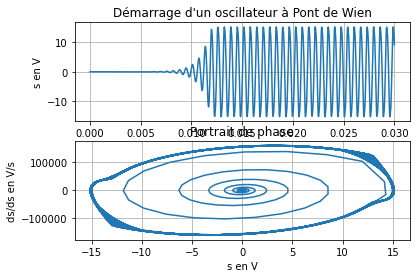

```python
import numpy as np
from scipy.integrate import odeint
import matplotlib.pyplot as plt

#définissons F

def F(Y,t,Q,w0,K,Vsat):
    if abs(Y[0])<Vsat:
        d2y=-w0**2*Y[0]-w0/Q*(1-K/3)*Y[1]
    else :
        d2y=-w0**2*Y[0]-w0/Q*Y[1]
    return Y[1],d2y

#posons les constantes

Q=1/3
R=1e3
C=1e-7
w0=1/(R*C)
Vsat=13

K=float(input("Donner la valeur de K :"))

#résolvons

t=np.linspace(0,30e-3,1000)
Y0=[0.0001,0.0001]

Y=odeint(F,Y0,t,args=(Q,w0,K,Vsat))

#traçons

plt.figure()
plt.subplot(211)
plt.plot(t,Y[:,0])
plt.grid()
plt.xlabel("Temps en s")
plt.ylabel ("s en V")
plt.title("Démarrage d'un oscillateur à Pont de Wien")

plt.subplot(212)
plt.plot(Y[:,0],Y[:,1])
plt.grid()
plt.xlabel("s en V")
plt.ylabel("ds/ds en V/s")
plt.title("Portrait de phase")
plt.show()
```

# Capacités Numériques au Programme

## Cartes de champ électrostatique

Grâce au programme Python accessible par [ce lien](https://notebook.basthon.fr/?from=https://simon-laurette.github.io/CN1_LignesChampE/CN1_ligneschampE.ipynb) , on peut déterminer la carte de champ électrostatique créée par un ensemble discret de charges positionnées en des points quelconques.

[figure not shown]

## Diffusion Thermique

Il est possible de résoudre l'équation de la diffusion thermique en régime transitoire à l'aide de [cette résolution numérique](https://notebook.basthon.fr/?from=https://simon-laurette.github.io/CN2_DiffusionThermique/CN_DiffusionThermique.ipynb).

[figure not shown]

## Slip Stick

On mène [ici](https://notebook.basthon.fr/?from=https://simon-laurette.github.io/CN3_SlipStick/SlipStick.ipynb) l'étude du phénomène de Slip-Stick qui consiste en une succession d'états d'adhérence et de glissement, auquel est confronté un système (craie qui crisse, archet sur une corde de violon...)

[figure not shown]

# Exemples de simulations intéressantes

## Le pendule animé

Retour à la table des matières

Avant d'étudier cette partie, il faut s'assurer d'avoir revu et compris comment résoudre une équation différentielle avec Python. On pourra passer un peu de temps sur l'exemple de résolution du pendule.

C'est bon ? Alors allons-y. Le but va être de fabriquer cette animation :

[figure not shown]

Choisissons d'abord un angle initial et une vitesse initiale pour le pendule :

```python
th0=float(input("Donner la valeur de l'angle initial en rad :"))
w00=float(input("Donner la valeur de la vitesse initiale en m/s :"))
```

Résolvons l'équation différentielle pour trouver $\theta$ et $\dot{\theta}$ à tout instant :

```python
import numpy as np
from scipy.integrate import odeint
from math import sin, cos
import matplotlib.pyplot as plt
import matplotlib
%matplotlib inline
matplotlib.rcParams['figure.figsize']=[8.0,8.0]

import numpy as np
import matplotlib.pyplot as plt

from IPython.display import HTML

#définissons la fonction F associée à l'équation différentielle
def F(Y,t,h,m,g,l):
    return Y[1],-h/m*Y[1]-g/l*sin(Y[0])

# définissons les paramètres du problème et les conditions initiales
y0=[th0,w00]

m=0.1
l=1
g=9.8
h=0.02

t=np.linspace(0,100,10000)
dt=t[1]-t[0]

#résolvons l'équation différentielle
Y=odeint(F,y0,t,args=(h,m,g,l))
```

A l'aide de la fonction `pos`, nous déterminons les coordonnées de l'extrémité du pendule. Nous créeons aussi les listes `temps`, `theta` et `thetapoint` qui grandiront au cours de l'animation et qui permettront de voir les graphes se tracer progressivement.

```python
def pos(theta):
    return sin(theta[-1]),-cos(theta[-1])

a,b=pos(theta)
```

On peut alors commencer à coder l'animation :

- on commence par préparer la figure (l'astuce est de laisser vide les arguments de la fonction `plot`, et de les remplir avec `set_data` à chaque itération).
- on crée ensuite une fonction `ìnitial` initialisant le tracé
- on crée enfin la fonction `animate` qui s'exécutera en boucle

On peut ensuite démarrer l'animation. Préparons tout d'abord la figure :

```python
import matplotlib.animation as animation

fig=plt.figure()
fig.clf()

plt.subplot(221)
l01, =plt.plot([],[],'-')
plt.xlim(-2,2)
plt.ylim(-2,2)

plt.subplot(222)
l1, =plt.plot([],[],'.-')#(t,y[:,0])
plt.xlim(0,20)
plt.ylim(np.min(Y[:,0]),np.max(Y[:,0]))
plt.xlabel("t en s")
plt.ylabel("Angle theta en rad")
plt.title("Révolutions/Oscillations d'un pendule")
plt.grid()

plt.subplot(223)
l2, =plt.plot([],[],'.-')#(y[:,0],y[:,1])
plt.xlabel("theta en rad")
plt.ylabel("theta point en rad/s")
plt.xlim(np.min(Y[:,0]),np.max(Y[:,0]))
plt.ylim(np.min(Y[:,1]),np.max(Y[:,1]))
plt.title("Portrait de phase")
plt.grid()
```

Et réalisons l'animation désormais :

```python
theta=[Y[0,0]]
thetapoint=[Y[0,1]]
temps=[0]

#fonction d'initialisation
def initial():
    global theta
    global thetapoint
    global Y
    global temps
    a,b=pos(theta)
    l01.set_data([0,a],[0,b])
    l1.set_data(t,theta)
    l2.set_data(theta,thetapoint)

#fonction d'animation
def animate(i):
    global theta
    global thetapoint
    global Y
    global temps
    global dt
    global th0
    global w00

    temps.append(temps[-1]+5*dt)
    theta.append(Y[5*i,0])
    thetapoint.append(Y[5*i,1])
    a,b=pos(theta)
    l01.set_data([0,a],[0,b])
    l1.set_data(temps,theta)
    l2.set_data(theta,thetapoint)


HTML(animation.FuncAnimation(fig,animate,np.arange(1, int(len(t)/30)),repeat=False,init_func=initial).to_jshtml())
# c'est un peu long alors on s'arrête à 1/30 du temps total de calcul... modifiable si on a le temps...
# attention cela peut être long
```